# health data Melbourne

Author

Chris Jackson, Belen Zapata-Diomedi, Steve Pemberton

Published

August 8, 2024

# 1 Introduction

This document explains and produces estimates for the health model for JIBE Melbourne. The model initially has three stages where individuals are in a healthy state, might become diseased, and die from any causes (regardless health status). For this first iteration of the model we need estimates of incidence and all cause mortality. A second iteration will be to include prevalence of disease at baseline (as opposed to all individuals being healthy) and add a differential all cause mortality risk for individuals who have one or more diseases.

## 1.2 Inequalities in health

In Jibe we aim to represent inequalities in health, thus, we include inequalities in our estimates of health to the extend of this being possible using publicly available data.

We use the following method to disaggregate an event rate (for example, incidence or mortality by age and sex) by a further risk factor (such as socio-economic status). Given

- the rate $r_{ave}$ by age and sex, averaged over people with or without the risk factor
- a relative (unstandardised) rate $RR$ between people with/without the risk factor
- the proportions of people with the risk factor $p_1$ and without the risk factor $p_0$

we can estimate the rates with ($r_1$) and without the risk factor ($r_0$), because if $r_{ave} = p_1 r_1 + p_0 r_0 = p_1 r_0 RR + p_0 r_0$, we can estimate $r_0 = r_{ave} / (p_1 RR + p_0)$.

$r_{ave} = r_1 \sum_{i=1}^G p_i RR_i$

we can compute $r_1$ given $r_{ave}$, the relative rates for the risk factor $RR_i$ and opulation proportions for the risk factor $p_i$. Hence we can compute the remaining $r_i$ by multiplying $r_1$ by $RR_i$.

# 2 Incidence data

## 2.1 Incidence data by age and sex

We use GBD data as the age and sex data for incidence estimates except for cancers. For cancers we use Australian Institute of Health and Welfare (AIHW) data and for mortality Australian Bureau of statistic (ABS) data.

### 2.1.1 Global Burden of disease data for Australia: data interpolation

```r
# GBD data for Melbourne.
gbd <- read.csv("health/original/GBD/gbd_incidence.csv")

# Filter data to needed variables and remove strings from GBD age variable and create from_age and to_age needed for interpolation.

gbdp <- gbd %>%
  filter(measure %in% "Incidence") %>%
  filter(metric %in% "Rate") %>%
  filter(year %in% 2018) %>%
  select(-c(location, upper, lower)) %>%
  filter(!cause %in% "All causes") %>%
  mutate(rate_1=val/100000) %>%
  # some ages have 'years' (eg 5-9 years), while others don't (eg 80-84); omit 'years'
  mutate(age = gsub(" years", "", age)) %>%
  tidyr::extract(age, c("from_age", "to_age"), "(.+)-(.+)", remove=FALSE, convert=TRUE) %>%
  mutate(from_age = case_when(age=="95+"  ~  95L,
                              age=="<5"  ~  0L,
                              TRUE  ~  from_age),
         to_age = case_when(age=="95+"  ~  99L,
                            age=="<5"  ~  4L,
                            TRUE  ~  to_age),
         agediff = to_age - from_age + 1,
          val1yr = rate_1) %>%
  #we do not distribute amongst age groups as it is a rate but assume same within age group
 rename(agegroup = age)


# Now stretch the data out using an index, to create a data frame with 1 row per year of age and create a variable for year of age. The age group rate repeats within single years of age in the group.
index <- rep(1:nrow(gbdp), gbdp$agediff)
gbdpyrd5 <- gbdp[index,] %>%
  mutate(ageyr = from_age + sequence(gbdp$agediff) - 1)
gbdpyrd5 <- gbdpyrd5 %>%
  select(measure, ageyr, sex, agegroup, from_age, to_age, cause, year, val1yr,rate_1)


# Interpolation function to create smooth data (Steve: Might move to a function folder, but need to ensure all data to interpolate has the same format)

# Spline

library(splines)

disagg_spline <- function(dat, key) {
  epsilon <- 1e-6  # Small constant to avoid log(0)

  with(dat, {
    # Define the x and y for interpolation
    x <- seq(from = floor(min(from_age)/5) * 5, to = 100, by = 5)

    # browser() #useful for checking that x is what we expect. Can be used at any steps that we want
    # to check the data and works when running the function by stoping the process.

    # Add epsilon and log-transform the rates
    y <- log(rate_1 + epsilon)

    # Generate new x points (high-frequency), constrained to be at most 99
    new_x <- seq(min(x), min(99, max(x)), length.out = min(100, max(x) - min(x) + 1))

     # browser()

    # Perform spline interpolation on the log-transformed data
    log_interpolated <- spline(x, y, xout = new_x)$y

    # Transform back from log scale by exponentiating
    interpolated <- exp(log_interpolated)

    # Ensure that negative values do not occur after transformation
    interpolated[interpolated < 0] <- 0

    # Create a data frame with the interpolated values
    data.frame(
      ageyr = new_x,
      val_interpolated = interpolated
    )
  })
}

# Polinomial

disagg_polynomial <- function(dat, key) {
  with(dat, {
    x <- seq(from = floor(min(from_age)/5) * 5, to = 100, by = 5)
    y <- rate_1

    # Fit a polynomial model
    fit <- lm(y ~ poly(x, 3))  # 3rd-degree polynomial (adjust degree as needed)

    # Generate new x points
    new_x <- seq(min(x), min(99, max(x)), length.out = min(100, max(x) - min(x) + 1))

    # Predict values
    interpolated <- predict(fit, newdata = data.frame(x = new_x))

    # Ensure that negative values do not occur
    interpolated[interpolated < 0] <- 0

    # Create a data frame with the interpolated values
    data.frame(
      ageyr = new_x,
      val_interpolated = interpolated
    )
  })
}

##Loess

disagg_loess <- function(dat, key) {
  with(dat, {
    x <- seq(from = floor(min(from_age)/5) * 5, to = 100, by = 5)
    y <- rate_1

    # Fit a loess model
    fit <- loess(y ~ x)

    # Generate new x points
    new_x <- seq(min(x), min(99, max(x)), length.out = min(100, max(x) - min(x) + 1))

    # Predict values
    interpolated <- predict(fit, newdata = data.frame(x = new_x))

    # Ensure that negative values do not occur
    interpolated[interpolated < 0] <- 0

    # Create a data frame with the interpolated values
    data.frame(
      ageyr = new_x,
      val_interpolated = interpolated
    )
  })
}


# Smooth spline

disagg_smooth_spline <- function(dat, key) {
  epsilon <- 1e-6

  with(dat, {
    x <- seq(from = floor(min(from_age)/5) * 5, to = 99, by = 5)
    y <- log(rate_1 + epsilon)

    # browser()

    # Fit a smooth spline model
    fit <- smooth.spline(x, y)

    # browser()

    # Generate new x points
    new_x <- seq(min(x), min(99, max(x)), length.out = min(100, max(x) - min(x) + 1))

    # browser()

    # Predict values
    log_interpolated <- predict(fit, new_x)$y

      # browser()

    # Transform back from log scale
    interpolated <- exp(log_interpolated)

    # Ensure that negative values do not occur
    interpolated[interpolated < 0] <- 0

    # Create a data frame with the interpolated values
    data.frame(
      ageyr = new_x,
      val_interpolated = interpolated
    )
  })
}


# Apply the disaggregation function

# Group data for dissaggregation

gbdp_grp <- gbdp %>%
  group_by(measure, sex, cause) %>%
  arrange(measure, sex, cause, from_age)

# Apply function (select one of the above). Smooth_spline does a good job.
gbdpyr <- group_modify(gbdp_grp, disagg_smooth_spline) %>%
  ungroup()

#Join with original data where rates are the same within groups to validate interpolated data
gbdpyr <- gbdpyr %>%
  left_join(gbdpyrd5, by = c("measure", "ageyr", "sex", "cause"))

# Plot data to check interpolated values against 5-year age group values (original data)
## Four interpolation function could be use, the best fit should be used. For now, best fit to the data assessed visually.

# Melt the data to long format for ggplot
plot_data <- gbdpyr %>%
  select(measure, cause, sex, ageyr, rate_1, val_interpolated) %>%
  pivot_longer(cols = c(rate_1, val_interpolated), names_to = "type", values_to = "value")

# Define how many plots per page
nrow <- 3
ncol <- 2

# Create a combined cause and sex variable for faceting
plot_data <- plot_data %>%
  mutate(cause_sex = interaction(cause, sex))

# Define the number of unique facets
n_facets <- length(unique(plot_data$cause_sex))

# Calculate the number of pages needed
n_pages <- ceiling(n_facets / (nrow * ncol))

# Function to generate a plot for a specific page
plot_page <- function(page) {
  # Calculate the start and end index for the current page
  start <- (page - 1) * nrow * ncol + 1
  end <- min(page * nrow * ncol, n_facets)

  # Subset the data for the current page
  plot_data_subset <- plot_data %>%
    filter(cause_sex %in% unique(plot_data$cause_sex)[start:end])

  # Create the plot for the current page
  ggplot(plot_data_subset, aes(x = ageyr, y = value, color = type, linetype = type)) +
    geom_line() +
    facet_wrap(~ cause_sex, nrow = nrow, ncol = ncol, labeller = label_wrap_gen(width = 30)) +
    labs(title = "Original and Interpolated Rates",
         x = "Age",
         y = "Rate",
         color = "Rate Type",
         linetype = "Rate Type") +
    theme_minimal() +
    theme(
      legend.title = element_blank(),
      panel.background = element_rect(fill = "white"),
      plot.background = element_rect(fill = "white"),
      panel.grid.major = element_line(color = "gray80"),
      panel.grid.minor = element_line(color = "gray90")
    )
}

# Generate and save all pages
output_dir <- "docs/images/cancer_gbd_age_sex/"
if (!dir.exists(output_dir)) {
  dir.create(output_dir, recursive = TRUE)
}


for (page in 1:n_pages) {
  p <- plot_page(page)
  file_path <- file.path(output_dir, paste0("plot_page_", page, ".png"))
  ggsave(filename = file_path, plot = p, width = 12, height = 8, bg = "white")
}
```

### 2.1.2 Australian Institute of Health and Welfare data for Australia: data interpolation

For cancers, we use data from AIHW, which similar to GBD, will be interpolated.

#### 2.1.2.1 Harmonise definitions of cancer sites

The cancer sites are reported differently between the AIHW tables on incidence by age/sex and incidence by socioeconomic quintiles.

This table details the assumptions that are made in order to match the corresponding rates between the tables. The sites that we intend to use are defined by stdname and ICD10. Each row of the table below details the site from the AIHW tables that these are assumed to be matched to.

Note, sites are the same as causes in GBD.

```r
sites <- rbind(
    ## Standard name,   Name in age/sex data,  Name in socio data,   Our intended ICD10,
    c("Breast cancer",   "Breast cancer"  ,      "Breast cancer in females (C50)" , "C50"),
     c("Endometrial cancer", "Endometrial cancer", "Uterine cancer (C54–C55)" ,  "C54–C55"),
      c("Lung cancer",       "Lung cancer",         "Lung cancer (C33–C34)",  "C33–C34"),
      c("Colon cancer",     "Colon cancer",         "Colorectal cancer (C18–C20)", "C18"),
      c("Esophageal cancer", "Oesophageal cancer" , NA,  "C15"),
      c("Liver cancer",      "Liver cancer",       "Liver cancer (C22)", "C22"),
      c("Kidney cancer",     "Kidney cancer",    "Kidney cancer (C64)", "C64"),
      c("Gastric cardia cancer",  "Stomach cancer", NA, "C16"),
      c("Myeloid leukemia", "Chronic myeloid leukaemia (CML)"  , NA, "C92.1"),
      c("Myeloma", "Multiple myeloma", NA, "C90.0"),
      c("Head and neck cancer", "Head and neck cancer (including lip)", "Head and neck cancers (with lip) (C00–C14, C30–C32)", "C01–C14, C30–C32"),
      c("Rectum cancer", "Rectal cancer (including rectosigmoid junction)", "Colorectal cancer (C18–C20)", "C20"),
      c("Bladder cancer", "Bladder cancer", "Bladder cancer (C67)", "C67"),
      c("Prostate cancer", "Prostate cancer", "Prostate cancer (C61)", "C61"),
      c("Malignant melanoma", "Melanoma of the skin", "Melanoma of the skin (C43)", "C43"),
    c("All cancers", "All cancers combined", "All cancers combined (C00–C97, D45, D46, D47.1, D47.3–D47.5)", "C00–C97, D45, D46, D47.1, D47.3–D47.5")
    ) |>
    as_tibble() |>
    setNames(c("stdname","agesexname","socioname","ICD10") ) |>
    select(stdname, ICD10, agesexname, socioname)

## This table is causing error, to be fixed (2/08/2024)
knitr::kable(sites, col.names = c("Standardised name","ICD 10 code",
             "Closest site in age/sex data","Closest site in socioeconomic data"))
```

| Standardised name | ICD 10 code | Closest site in age/sex data | Closest site in socioeconomic data |
| --- | --- | --- | --- |
| Breast cancer | C50 | Breast cancer | Breast cancer in females (C50) |
| Endometrial cancer | C54–C55 | Endometrial cancer | Uterine cancer (C54–C55) |
| Lung cancer | C33–C34 | Lung cancer | Lung cancer (C33–C34) |
| Colon cancer | C18 | Colon cancer | Colorectal cancer (C18–C20) |
| Esophageal cancer | C15 | Oesophageal cancer | NA |
| Liver cancer | C22 | Liver cancer | Liver cancer (C22) |
| Kidney cancer | C64 | Kidney cancer | Kidney cancer (C64) |
| Gastric cardia cancer | C16 | Stomach cancer | NA |
| Myeloid leukemia | C92.1 | Chronic myeloid leukaemia (CML) | NA |
| Myeloma | C90.0 | Multiple myeloma | NA |
| Head and neck cancer | C01–C14, C30–C32 | Head and neck cancer (including lip) | Head and neck cancers (with lip) (C00–C14, C30–C32) |
| Rectum cancer | C20 | Rectal cancer (including rectosigmoid junction) | Colorectal cancer (C18–C20) |
| Bladder cancer | C67 | Bladder cancer | Bladder cancer (C67) |
| Prostate cancer | C61 | Prostate cancer | Prostate cancer (C61) |
| Malignant melanoma | C43 | Melanoma of the skin | Melanoma of the skin (C43) |
| All cancers | C00–C97, D45, D46, D47.1, D47.3–D47.5 | All cancers combined | All cancers combined (C00–C97, D45, D46, D47.1, D47.3–D47.5) |

```r
# assume unique row in age-sex data for each standard site
stopifnot(!any(duplicated(sites$agesexname)))
```

## 2.2 Inequalities

Above data is by age and sex, but we are interested in further disaggregation to represent inequalities in health. Preparation of inequalities data responds to inequality availability data for the following groups of diseases or single diseases: cancer, cardiovascular diseases and diabetes, COPD. For depression we did not find any data representing inequalities. Data sources are outlined here (Steve maybe there is a better way to share a file): https://rmiteduau.sharepoint.com/:x:/r/sites/JIBEworkinggroup/Shared%20Documents/General/health/diseases%20data.xlsx?d=w39d6dfa0db7c4a3294a89cf8ad3f71ee&csf=1&web=1&e=do8erQ

### 2.2.1 Cancers

We have data from the Cancer Atlas, by SA2 area and for males, females and persons. This is modelled data and methods are explained here (https://atlas.cancer.org.au/developing-a-cancer-atlas/) and here (https://pubmed.ncbi.nlm.nih.gov/31570101/). Data is available for the below cancer types and by SA2 area defined by the Australian Statistical Geography Standard July 2011 edition, with data on Capital Cities for Australia so we can select Melbourne. I joined all diseases data for incidence, for males and females, by SA2 area. Data is for standardised incidence ratio (SIR). The SIR reflects the area-specific incidence rate relative to the Australian average. It is the ratio of the observed cancer cases to the expected number of cases, the latter adjusting for difference in population between SA2 and differences in age structure of the population with an SA2.

```r
# Get sheet with SA2 areas by SES and filter Victoria

library(readxl)

excel_file <- "health/original/ATLAS/Atlas_estimates_95CIs.xlsx"

# Get the names of the sheets in the Excel workbook
diseases <- excel_sheets(excel_file)[-c(1:4)]

## Males
all_data_males <- list()

# Loop through each disease
for (sheet_name in diseases) {
  # Read data for the current disease
  data <- read_xlsx(excel_file,
    sheet = sheet_name,
    skip = 9,
    col_names = TRUE,
    n_max = 2200
  )

  # Process data for males
  males <- data %>%
    select(1:5) %>%
    setNames(.[2, ]) %>%
    slice(-1, -2) %>%
    mutate(sex = "Males",
           site = sheet_name)

  # Store the processed data in the list
  all_data_males[[sheet_name]] <- males
}

# Bind all data frames together
final_data_males <- do.call(rbind, all_data_males)



## females
all_data_females <- list()

# Loop through each disease
for (sheet_name in diseases) {
  # Read data for the current disease
  data <- read_xlsx(excel_file,
    sheet = sheet_name,
    skip = 9,
    col_names = TRUE,
    n_max = 2200
  )

  # Process data for males
  females <- data %>%
    select(1,2,6,7,8) %>%
  setNames(.[2, ]) %>%
  slice(-1, -2) %>%
  mutate(sex="Females",
           site = sheet_name)

  # Store the processed data in the list
  all_data_females[[sheet_name]] <- females
}

# Bind all data frames together
final_data_females <- do.call(rbind, all_data_females)

SA2_soc <- read_xlsx(excel_file, sheet="Geography", skip=11, col_names = TRUE, n_max=2200)

data_combined <- bind_rows(final_data_females, final_data_males) %>%
  mutate(`SA2 code`=as.numeric(`SA2 code`)) %>%
 left_join(SA2_soc) %>% rename(SA2 = `SA2 name`)
# %>% filter(State=="Victoria", Remoteness=="Major city", `Capital cities`=="Greater Melbourne")
```

**Combining data sources**

I combined incidence data by age and sex for Australia wide with data for SA2 area. Data for SA2 area (data_combined) from the Atlas gives us the SIR, which is interpreted as the relative rate of incidence for an area, by sex to the Australian average. The Australian average is from AIHW and already stretched to one year age groups in data incyr.

Select data for health model in JIBE. Rate by sex, age and area is simply created by multiplying Standardized Incidence Rate (SIR) by age and sex rate.

```r
#Select diseases from ATLAS combined data
data_combined <- data_combined %>% filter(!(site %in% c("Brain Cancer", "Cervical Cancer", "Myeloproliferative neoplasms", "Non-Hodgkin Lymphoma", "Ovarian Cancer", "Pancreatic Cancer", "Thyroid Cancer"))) %>% mutate(site=tolower(site))
#

# Atlas does not have data for bladder cancer, use data for all cancers and for colon and rectum separately, then ues combined (bowel cancer) for each.

bladder_cancer <- data_combined %>% filter(site=="all cancers") %>%
  mutate(site = if_else(site == "all cancers", "bladder cancer", site))

rectum_cancer <- data_combined %>% filter(site=="bowel cancer") %>%
  mutate(site = if_else(site == "bowel cancer", "rectum cancer", site))

data_sa2_sex <- data_combined %>%
  mutate(site = if_else(site == "bowel cancer", "colon cancer", site)) %>%
           bind_rows(bladder_cancer, rectum_cancer) %>%
  mutate(site = if_else(site == "uterine cancer", "endometrial cancer", site),
         site = if_else(site == "oesophageal cancer", "esophageal cancer", site),
         site = if_else(site == "melanoma", "malignant melanoma", site),
         site = if_else(site == "stomach cancer", "gastric cardia cancer", site),
         site = if_else(site == "leukaemia", "myeloid leukemia", site),
         site = ifelse(site == "head and neck cancers", "head and neck cancer", site))


## Combine with incidence data by age and sex

data_sa2_sex_age <- data_sa2_sex %>% left_join(incyr, by=c("sex", "site")) %>%
  mutate(rate_area=as.numeric(SIR)*val_interpolated) %>%
  rename(socio=`Socioeconomic status`)

# Save in final folder

cancer_incidence_area <- data_sa2_sex_age %>% rename (sa2_code=`SA2 code`,
                                                      sa2_name = SA2) %>%
  mutate(prob=1 - exp(-rate_area)) %>%
  select(sa2_code, sa2_name, socio, site, age = ageyr, sex, prob, rate_area, val_interpolated) %>%
  mutate(rate_ave_age_sex=val_interpolated*100000)

saveRDS(cancer_incidence_area, file="health/processed/cancer_incidence_area.rds")

## Compare data per SA2 and sex and data from national administrative sources by age, sex and combined with level of deprivation (Chris, see cancer incidence.Rmd)

compare_socio <- cancer_incidence_area %>%
group_by(age, sex, site, socio, rate_ave_age_sex, .groups = "drop") %>%
summarise(rate_area = round(mean(rate_area, na.rm = TRUE), 7), .groups = "drop") %>% mutate(socio=as.factor(socio)) %>%
  filter(socio != "Not classified") %>%
  mutate(sex = case_when(
    sex == "Females" ~ "Female",
    sex == "Males" ~ "Male"
  )) %>%
  mutate(rate_area=rate_area*100000)

cancerinc <- readRDS("health/processed/cancer_incidence.rds")

cancerinc <- cancerinc %>%
  mutate(socio = case_when(
    socio == "1 (most deprived)" ~ "Most disadvantaged",
    socio == "2" ~ "Disadvantaged",
    socio == "3" ~ "Middle SES",
    socio == "4" ~ "Advantaged",
    socio == "5 (least deprived)" ~ "Most advantaged",
    TRUE ~ socio  # Handle default case
  )) %>%
mutate(socio=as.factor(socio)) %>%
  ungroup() %>%
  mutate(site=tolower(site))

compare_socio <- compare_socio %>% left_join(cancerinc, by=c("site", "age", "sex", "socio")) %>%
  mutate(rate_soc=round(rate, 2)) %>% select(!rate)

compare_socio <- na.omit(compare_socio)

# is.na(compare_socio) #  this is to check for na values, there might be some if males for instance are assigned breast cancer or females prostate cancer.
```

**THESE GRAPHS CODE NEEDS CHECKING, THE IDEA IS TO COMPARE RATES CALCULATED WITH ATLAS DATA, WITH AIHW DATA (CHRIS) AND AVERAGE BY AGE AND SEX FROM AIHW INTERPOLATED.**

**STEVE CAN YOU PLEASE HELP WITH CHECKING THE DATA. rate_area is grouped by socio economic status to compare with rate_soc from data generated by Chris. Then I added the rate_ave_age_sex which is the aihw age and sex data. The idea is to check that the data makes sense, for example, we would expect the lowest socio economic rate for both rate_area and rate_soc to be higher than the rate_ave_age_sex. Note that the rate_soc data was not interpolated, hence the steps (this can be done if you wish to, code is available)**

**SP note: I’ve checked the graphs (note also that I’ve re-ordered them so that levels are shown in order of disadvantage from top to bottom). Most show the expected pattern of most disadvantaged having incidence above average through to most advantaged having incidence below average. Following are the exceptions:**

- **breast cancer (F) and prostate cancer (M) show the reverse pattern, with most disadvantaged having lowest incidence.**
- **gastric cancer (F&M) have all groups being below average.**
- **liver cancer (F) has all groups below average.**
- **malignant melanoma (F&M) show an inconsistent pattern with most results above average.**
- **myeloid leukemia (F&M) show little differentiation between socio economic groups.**
- **myeloma (F&M) have most groups at or below average.**

**There is little variation for all cancers (F&M), which is not surprising as they would show the combined effect of cancers with highest incidence in disadvantaged areas and others with highest incidence in advantaged areas.**

Each graph created below for each site and sex combinations depicts five graphs within representing each socioeconomic group, and within each graph by socioeconomic group a line called rate which represents the rate by age and sex for Australia wide (incyr), the rate derived from age and sex and age standardised rates by socioeconomic group called rate_soc (derived by Chris) and rate derived from data by sex and SA2 and rates by age and sex (rate_area).

```r
library(ggplot2)
rates_compare_long <- compare_socio %>%
  mutate(socio = factor(socio,
                        levels = c("Most disadvantaged", "Disadvantaged",
                                   "Middle SES", "Advantaged",
                                   "Most advantaged", "Not classified"))) %>%
  pivot_longer(
  cols = c(rate_area, rate_soc, rate_ave_age_sex),
  values_to = "rate",
  names_to = "rate_type"
)



# Create folder if it doesn't exist
folder_path <- file.path("docs", "images", "cancer_inc_compare")
if (!file.exists(folder_path)) {
  dir.create(folder_path, recursive = TRUE)
}

# Define colors for rate types
rate_type_colors <- c("black", "red", "blue")

# Loop over each combination of site and sex
for (site_val in unique(rates_compare_long$site)) {
  for (sex_val in unique(rates_compare_long$sex)) {
    # Skip certain combinations of sex and site
    if ((sex_val == "Male" && site_val %in% c("breast cancer", "endometrial cancer")) ||
        (sex_val == "Female" && site_val == "prostate cancer")) {
      cat("Skipping graph for sex:", sex_val, "and site:", site_val, "\n")
      next  # Skip to the next iteration of the loop
    }

    cat("Processing site:", site_val, "and sex:", sex_val, "\n")  # Debug print statement

    # Subset data for the current combination of site and sex
    plot_data <- subset(rates_compare_long, site == site_val & sex == sex_val)

    # Check if there are data for the current combination
    if (nrow(plot_data) > 0) {
      max_rate <- max(plot_data$rate, na.rm = TRUE)
      cat("Maximum rate:", max_rate, "\n")  # Debug print statement

      # Create ggplot for the current combination
      p <- ggplot(plot_data, aes(x = age, y = rate, col = rate_type)) +
        geom_line(lwd = 1, aes(linetype = NULL)) +
        scale_color_manual(values = rate_type_colors) +
        facet_wrap(~socio, scales = "free_y", ncol = 1) + # Nested facet wrap for socio-economic status
        ylab("Incidence rate (per 100,000)") +
        xlab("Age (years)") +
        coord_cartesian(xlim = c(25, 90)) +
        scale_y_continuous(breaks = seq(0, max_rate, by = 400)) +  # Adjust y-axis breaks
        guides(alpha = FALSE, col = guide_legend(title = "Rate Type")) +
        theme(legend.position = "bottom", legend.box = "horizontal", legend.box.just = "center",
              legend.margin = margin(t = 5, unit = "pt"), legend.spacing = unit(0.2, "cm"))

      # Save the ggplot for the current combination
      png_name <- file.path(folder_path, paste0(site_val, "_", sex_val, ".png"))
      ggsave(png_name, plot = p + labs(title = paste("| Site:", site_val, "| Sex:", sex_val)), device = "png")
    } else {
      cat("No data for site:", site_val, "and sex:", sex_val, "\n")  # Debug print statement
    }
  }
}
```

```
Processing site: all cancers and sex: Female
Maximum rate: 2292
```

```
Processing site: all cancers and sex: Male
Maximum rate: 3843
```

```
Processing site: bladder cancer and sex: Female
Maximum rate: 84.86
```

```
Processing site: bladder cancer and sex: Male
Maximum rate: 266.9
```

```
Processing site: breast cancer and sex: Female
Maximum rate: 473.2
```

```
Skipping graph for sex: Male and site: breast cancer
Processing site: colon cancer and sex: Female
Maximum rate: 317.3
```

```
Processing site: colon cancer and sex: Male
Maximum rate: 360.1
```

```
Processing site: endometrial cancer and sex: Female
Maximum rate: 74.45
```

```
Skipping graph for sex: Male and site: endometrial cancer
Processing site: esophageal cancer and sex: Female
Maximum rate: 32.88
```

```
Processing site: esophageal cancer and sex: Male
Maximum rate: 59.61
```

```
Processing site: gastric cardia cancer and sex: Female
Maximum rate: 57.79
```

```
Processing site: gastric cardia cancer and sex: Male
Maximum rate: 95.62
```

```
Processing site: head and neck cancer and sex: Female
Maximum rate: 61.83
```

```
Processing site: head and neck cancer and sex: Male
Maximum rate: 134.8
```

```
Processing site: kidney cancer and sex: Female
Maximum rate: 45.38
```

```
Processing site: kidney cancer and sex: Male
Maximum rate: 93.42
```

```
Processing site: liver cancer and sex: Female
Maximum rate: 44.26
```

```
Processing site: liver cancer and sex: Male
Maximum rate: 85.52
```

```
Processing site: lung cancer and sex: Female
Maximum rate: 319.9
```

```
Processing site: lung cancer and sex: Male
Maximum rate: 619.1
```

```
Processing site: malignant melanoma and sex: Female
Maximum rate: 205.8
```

```
Processing site: malignant melanoma and sex: Male
Maximum rate: 423.8
```

```
Processing site: myeloid leukemia and sex: Female
Maximum rate: 6.5
```

```
Processing site: myeloid leukemia and sex: Male
Maximum rate: 20.56
```

```
Processing site: myeloma and sex: Female
Maximum rate: 43.69
```

```
Processing site: myeloma and sex: Male
Maximum rate: 77.38
```

```
Processing site: rectum cancer and sex: Female
Maximum rate: 79.25
```

```
Processing site: rectum cancer and sex: Male
Maximum rate: 142
```

```
Skipping graph for sex: Female and site: prostate cancer
Processing site: prostate cancer and sex: Male
Maximum rate: 922.6
```

```r
# Second comparison difference between rate_soc and rate area

compare_diff <- compare_socio %>%
  mutate(diff_rate = ifelse(rate_area == 0 | rate_soc == 0, 0, ((rate_area - rate_soc) / rate_soc) * 100))
```

#### 2.2.1.1 Notes on comparison data sources

In general, rates calculated by Chris with AIHW data and rates derived from ATLAS data are very similar, with small discrepancies for cancer with small incidence rates.

Esophageal cancer rates for males are higher and lower respectively for disadvantaged and most disadvantage and most advantaged when usisng rates based on areas (ATLAS) data. Rates from socioeconomic status (from AIHW data) for esophageal cancer were assumed to follow the same patterns as all cancers.

For gastric cardia, for both males and females, rates based on areas (ATLAS) are slightly lower than from socio-economic data (AIHW) for males and females disadvantaged, most advantaged and advantaged groups.

For head and neck, rates for males and females from area rates (ATLAS) are more conservative than with AIHW, for example, for the advantaged group, area rates are higher than rates from socioeconomic data (AIHW). Similar pattern with liver cancer and lung cancer.

### 2.2.2 Cardiovascular diseases, type 2 diabetes and COPD

**STEVE, can you please paste the code below from cardiovascular_incidence.RDM. Please replace ensure that the incidence by age and sex is from the interpolated file (incyr (feel free to change to a better name accross the file). [SP note: done, below; using GBD for this, so I’ve used the interpolated file ‘gbdpyr’. And please also note that I’ve included COPD here along with the other non-cancer diseases, as the structure of the two original .rmd files was so similar.]**

This script produces estimates of incidence for stroke, ischemic heart disease , type 2 diabetes and chronic obstructive pulmonary disease (COPD) by age, sex and area socioeconomic quintile, for Australia using data for 2016 and 2018.

The data is obtained from the Global Burden of Disease for disease incidence by age and sex and from AIHW by sex and socioeconomic status (JIBE data summary spreadsheet). There is no unique source of data for what we need, hence the combination of data sources. Source files:

Incidence by 5-year age group and sex for stroke, ischemic heart disease and type 2 diabetes:

- `gbd_incidence.csv` (available from GBD data tool, data is for 2018, baseline year for the jibe model)

Incidence, death and prevalence by sex and socioeconomic area for 2016 (stroke, ischemic heart disease and type 2 diabetes) or 2017-18 (COPD). We do not have data for incidence by socioeconomic area for all diseases of interest, hence, we use deaths and prevalence, depending which one is more suitable.

These data refer to the whole of Australia, and we do not have area specific data (e.g. SA2 as we do with mortality). These data are combined to produce estimates for each of stroke, ischemic heart disease, type 2 diabetes and COPD by age, sex and area socioeconomic quintile. This assumes that the effect of socioeconomic status on the incidence of these diseases is the same for all age and sex groups.

#### 2.2.2.1 Incidence by age and sex

Data by year of age is interpolated as above.

```r
inc_cvd_dia_copd_agesex <- gbdpyr %>%
  filter (cause %in% c("Stroke", "Ischemic heart disease", "Diabetes mellitus type 2",
                       "Chronic obstructive pulmonary disease")) %>%
  dplyr::select(cause, age = ageyr, sex, rate = val_interpolated)
```

#### 2.2.2.2 Incidence by socioeconomic status and sex

- Socioeconomic areas are classified according to population-based quintiles using the Index of Relative Socio-Economic Disadvantage (IRSD) based on Statistical Area Level 2 (SA2) of usual residence.
- The below data sources are then used to adjust GBD data by age and sex to also be further dissaggregated by socioeconomic status.

```r
# Stroke

stroke_inc <- read_xlsx("health/original/AIHW/cdv_dia_kid_socioeconomic.xlsx", sheet="Table S2", skip=1, col_names = TRUE, n_max=30) %>%
  slice(-c(7:11, 18:26)) %>%
  mutate(sex = ifelse(row_number() <= 6, "Male", "Female")) %>%
  slice(-c(1,7)) %>%
  rename(socio=`Socioeconomic group`,
         rate=`2016`) %>%
  mutate(socio = case_when(socio=="Group 1 (lowest)" ~ "1", # 1: lowest, to 5: highest
                           socio=="Group 2" ~ "2",
                           socio=="Group 3" ~ "3",
                           socio=="Group 4" ~ "4",
                           socio=="Group 5 (highest)" ~ "5",
                           .default = socio),
         socio = as.numeric(socio)) %>%
  group_by(sex) %>%
  mutate(rr = rate / first(rate)) |>
  ungroup() %>%
  select(socio, sex, rate, rr) %>%
  mutate(cause="Stroke") # to match gbd name

# Cardiovascular disease (data is for deaths but we will use it to adjust incidence by age and sex)

cvd_inc <- read_xlsx("health/original/AIHW/cdv_dia_kid_socioeconomic.xlsx", sheet="Table S3", skip=1, col_names = TRUE, n_max=30) %>%
  slice(-c(7:11, 18:26)) %>%
  mutate(sex = ifelse(row_number() <= 6, "Male", "Female")) %>%
  slice(-c(1,7)) %>%
  rename(socio=`Socioeconomic group`,
         rate=`2016`) %>%
  mutate(socio = case_when(socio=="Group 1 (lowest)" ~ "1", # 1: lowest, to 5: highest
                           socio=="Group 2" ~ "2",
                           socio=="Group 3" ~ "3",
                           socio=="Group 4" ~ "4",
                           socio=="Group 5 (highest)" ~ "5",
                           .default = socio),
         socio = as.numeric(socio)) %>%
  group_by(sex) %>%
  mutate(rr = rate / first(rate)) |>
  ungroup() %>%
  select(socio, sex, rate, rr) %>%
  mutate(cause="Ischemic heart disease") # to match gbd name


# Diabetes (we use prevalence data. There is mortality data, but figures are low and diabetes as cause of deaths is likely under reported)

diabetes_inc <- read_xlsx("health/original/AIHW/cdv_dia_kid_socioeconomic.xlsx", sheet="Table S7", skip=1, col_names = TRUE, n_max=30) %>%
  slice(-c(7:11, 18:26)) %>%
  mutate(sex = ifelse(row_number() <= 6, "Male", "Female")) %>%
  slice(-c(1,7,13)) %>%
  rename(socio=`Socioeconomic group`,
         rate=`2016`) %>%
  mutate(socio = case_when(socio=="Group 1 (lowest)" ~ "1", # 1: lowest, to 5: highest
                           socio=="Group 2" ~ "2",
                           socio=="Group 3" ~ "3",
                           socio=="Group 4" ~ "4",
                           socio=="Group 5 (highest)" ~ "5",
                           .default = socio),
         socio = as.numeric(socio)) %>%
  group_by(sex) %>%
  mutate(rr = rate / first(rate)) |>
  ungroup() %>%
  select(socio, sex, rate, rr) %>%
  mutate(cause="Diabetes mellitus type 2") #to match gbd name

# COPD (we use prevalence data)

copd_inc <- read_xlsx("health/original/AIHW/copd-prevalence.xlsx", sheet="Table 1.2", skip=2,
                      col_names = TRUE, n_max=10) %>%
  slice(-c(1:5)) %>%
  rename_with( ~ c("socio", "Male", "MaleCI", "Female", "FemaleCI", "Person", "PersonCI")) %>%
  dplyr::select(socio, Male, Female) %>%
  pivot_longer(cols = c("Male", "Female"), names_to = "sex", values_to = "rate") %>%
  mutate(socio = case_when(socio == "1 (lowest)" ~ "1", # 1: lowest, to 5: highest
                           socio == "5 (highest)" ~ "5",
                           .default = socio),
         socio = as.numeric(socio)) %>%
  group_by(sex) %>%
  mutate(rr = rate / first(rate)) %>%
  ungroup() %>%
  select(socio, sex, rate, rr) %>%
  mutate(cause="Chronic obstructive pulmonary disease") # to match gbd name

# Combined database with all four diseases

cvd_dia_copd_socio <- bind_rows(cvd_inc, diabetes_inc, stroke_inc, copd_inc) %>%
  arrange(cause, sex, socio)
```

#### 2.2.2.3 Combining socioeconomic status with age and sex

We use the method outlined in `Inequalities in health` above to disaggregate the age and sex data by socioeconomic status.

The code to perform this disaggregation works by stretching out the age/sex incidence data vertically to create a dataset with one row per combination of age, sex and socioeconomic quintile. This is then joined with the dataset on relative incidence by socioeconomic quintiles. The term $\sum_{i=1}^G p_i RR_i$ is then computed as `sum_pRR`, and joined to the streched incidence dataset. This allows the disaggregated rates `rate` to be computed in a vectorised way.

```r
cvd_dia_copd_inc <- inc_cvd_dia_copd_agesex %>%
    slice(rep(row_number(), each=5)) %>%
    mutate(socio = rep(1:5, length.out=n())) %>%
    left_join(cvd_dia_copd_socio %>% select(cause, sex, socio, rr_socio = rr),
              by = c("cause", "sex", "socio")) %>%
    mutate(p_socio = 1/5,    # assumption
           pRR = p_socio * rr_socio,
           socio = ordered(socio))

sum_p <- cvd_dia_copd_inc %>%
    group_by(cause, age, sex) %>%
    summarise(sum_pRR = sum(pRR), .groups="drop")

cvd_dia_copd_inc <- cvd_dia_copd_inc %>%
    left_join(sum_p, by=c("cause", "age", "sex")) %>%
    mutate(rate_soc = rate * rr_socio / sum_pRR,
           socio = ordered(socio, labels = c("1 (most deprived)",
                                             "2","3","4",
                                             "5 (least deprived)")),
           sex = factor(sex))

saveRDS(cvd_dia_copd_inc, file="health/processed/cvd_dia_copd_incidence.rds")
```

We are left with the incidence by age, sex and socioeconomic status in the variable `rate_soc`. The final dataset is saved in the file `cvd_dia_copd_incidence.rds`

#### 2.2.2.4 Illustration of incidence estimates

Incidence by age, sex and socioeconomic quintile for ischemic heart disease, stroke, type 2 diabetes and COPD.

The published incidence by age and sex (averaged over deprivation levels) is shown by the dotted black lines (original gbd data interpolated from 5 year age groups to one year). The estimated incidence disaggregated by socioeconomic quintile is shown by the coloured lines, with socioeconomic status indicated by the lightness of the lines (calculated from gbd data and aihw data).

The relative risk between socioeconomic quintiles is assumed to be the same between different age/sex groups, but the average of the deprivation-specific estimates is constrained to be the same as the published average.

All plots show the expected outcome of the highest levels of incidence at the highest levels of disadvantage.

```r
# plot of data
p <- ggplot(cvd_dia_copd_inc,
       aes(x=age, y=rate_soc, col=sex, alpha=socio)) +
    geom_line(lwd=1.5) +
    geom_line(data=inc_cvd_dia_copd_agesex,
              aes(x=age, y=rate, group=sex),
              inherit.aes = FALSE,
              lwd=1, lty=2, alpha=0.4, col="black") +
    facet_wrap(~cause, ncol=2, scales="free_y") +
    ylab("Incidence rate (per 100,000)") +
    xlab("Age (years)") +
    coord_cartesian(xlim=c(25, 90)) +
    guides(alpha=guide_legend(title=NULL),
           col=guide_legend(title=NULL)) +
    theme(legend.position = "bottom")

# save plot
# Generate and save all pages
output_dir <- "docs/images/cvd_dia_copd_inc/"
if (!dir.exists(output_dir)) {
  dir.create(output_dir, recursive = TRUE)
}

ggsave(filename = paste0(output_dir, "cvd_dia_copd_incidence.png"), plot = p,
       width = 12, height = 12, bg = "white")
```

# 3 Mortality data

This section shows how mortality data for the JIBE Melbourne microsimulation is obtained and processed, giving the R code to reproduce the analysis.

The aim is to produce data describing the annual risk of death for a synthetic individual in the microsimulation model.

This is defined here as a a function of the individual’s age and sex, area of residence and level of education.

It is calculated based on a combination of routinely-collected data sources, under the assumption that age and sex, small area of residence and level of education are independent risk factors for mortality.

## 3.1 Data sources

### 3.1.1 2016 Australian geography definitions

Statistical Areas level 2 (SA2), as defined for the 2016 census, are used as the definition of area of residence here. This data file defines the SA2 areas and their mapping to larger areas.

[Source](https://www.abs.gov.au/ausstats/abs@.nsf/mf/1270.0.55.001)

```r
sa2 <- read_csv("health/original/ABS/SA2_2016_AUST.csv", col_types = "cccccccccccd")
```

### 3.1.2 Mortality by year of age and sex, for Victoria state (not by smaller areas)

[Source](https://www.abs.gov.au/methodologies/life-tables-methodology/2016-2018)

The mortality rate here, `rate`, is defined as “the proportion of persons dying between exact age x and exact age x+1”. For presentation, this is converted to a rate per 1000 people.

```r
dats <- read.csv("health/original/ABS/3302055001do001_20162018_Table_1.2.csv",skip=6,
         na=c("","np"), nrows=101)[,1:9]
mf <- rep(c("male","female"),each=4)
names1 <- rep(c("denom","rate","personyears","le"), 2)
names(dats) <- c("age",paste(mf, names1, sep="_"))

victoria_lifetable <- dats |>
  pivot_longer(-age,
               names_to = c("sex","measure"),
               names_sep = "_") |>
  pivot_wider(names_from="measure", values_from=value) |>
  mutate(rate1000 = rate*1000,
         sex = factor(sex,
                      labels=stringr::str_to_title(sort(unique(.data$sex)))),
         sex = relevel(sex, "Male"))
```

### 3.1.3 Mortality by SA2 small areas in Victoria (not by age and sex)

[Source](https://adp-access.aurin.org.au/dataset/au-govt-abs-abs-deaths-sa2-2012-2020-sa2-2016)

This is provided as a JSON file, rather than a tabular format, so the R processing is more complex here.

The *standardised death rate* is published here. This is the expected number of deaths in the area if the age/sex balance of the area were same as a standard population. This can be compared between areas to describe the excess risk in each area not explainable by differences in age/sex balance.

An area-specific relative rate, relative to the average in the state, is computed by dividing the (published) standardised rate for that area by the average standardised rate. The average standardised rate is computed as a weighted average, weighted by the population in each area

```r
deaths_sa2 <- rjson::fromJSON(file="health/original/aurin/au-govt-abs-abs-deaths-sa2-2012-2020-sa2-2016.json") |>
  pluck("features") |>
  tibble() |>
  set_names("area") |>
  unnest_wider(area) |>
  select(properties) |>
  unnest_wider(properties) |>
  select(sa2_code,
         sa2_name,
         pop="_2016_estimated_resident_population_persons",
         deaths="_2016_deaths_no",
         stdrate="_2016_standardised_death_rate_rate") |>
  mutate(stdrate = as.numeric(ifelse(stdrate=="np", NA, stdrate)))
```

For some SA2 areas, standardised death rates are not published. As explained in the source: “crude rates and Age-standardised Death Rates (SDRs) based on small numbers are volatile and unreliable. SDRs based on less than 20 deaths and crude rates based on a very low death count have not been published and appear as ‘np’.”.

In these cases, the standardised death rate for the equivalent SA3 area is used here, from the following [source](https://data.aurin.org.au/dataset/au-govt-abs-abs-deaths-sa3-2012-2020-sa3-2016) in the same format as the SA2 data.

```r
deaths_sa3 <- rjson::fromJSON(file="health/original/aurin/au-govt-abs-abs-deaths-sa3-2012-2020-sa3-2016.json") |>
  pluck("features") |>
  tibble() |>
  set_names("area") |>
  unnest_wider(area) |>
  select(properties) |>
  unnest_wider(properties) |>
  select(sa3_code,
         sa3_name,
         pop="_2016_estimated_resident_population_persons",
         deaths="_2016_deaths_no",
         stdrate="_2016_standardised_death_rate_rate") |>
  mutate(stdrate = as.numeric(ifelse(stdrate=="np", NA, stdrate)))
```

Finally, a relative mortality rate `RR` is produced for each area, defined as the rate relative to the average mortality in the state `stdrate_ave`. This average mortality is defined as a weighted average of the area-specific rates, weighted by the population of each area.

```r
victoria_sa2_deaths <- deaths_sa2 |>
  left_join(sa2, join_by(sa2_code == SA2_MAINCODE_2016)) |>
  filter(STATE_NAME_2016=="Victoria") |>
  select(sa2_code, sa2_name, sa3_code = "SA3_CODE_2016", pop, deaths, stdrate) |>
  mutate(stdrate_ave = with(.data, sum(stdrate*pop,na.rm = TRUE)/sum(pop))) |>
  # Use SA3 rate if SA2 std rate is missing "np" due to small counts
  left_join(deaths_sa3 |> select(sa3_code, stdrate_sa3 = stdrate), by="sa3_code") |>
  mutate(stdrate = ifelse(is.na(stdrate), stdrate_sa3, stdrate)) |>
  mutate(RR = stdrate / stdrate_ave)

melbourne_sa2_deaths <- victoria_sa2_deaths |>
  filter(sa2_code %in% sa2$SA2_MAINCODE_2016[sa2$GCCSA_NAME_2016=="Greater Melbourne"])
```

### 3.1.4 Effects of education on mortality, by age

From [Welsh et al. 2021](https://doi.org/10.1093/ije/dyab080), Table 1. Age adjusted mortality rates per 100,000 people for high, medium and low education. Age groups 25-44, 45-64 and 65-84. For the whole of Australia, using data from the 2016 census linked to death registrations in 2016 and 2017.

```r
rate25 <- c(high=38.8, med=105, low=236)
rate45 <- c(219, 399, 724)
rate65 <- c(1551, 2201, 3202)
educ_mort <- as.data.frame(rbind(rate25, rate45, rate65)) |>
  mutate(rrmedium = med/high,
         rrlow = low/high,
         rrhigh = 1,
         agegroup = c("[25,45)", "[45,65)", "[65,85)")) |>
  pivot_longer(cols=c("rrhigh","rrmedium","rrlow"),
               names_to = "educ",
               names_prefix = "rr",
               values_to = "rr_educ") |>
  select(agegroup, educ, rr_educ)
```

### 3.1.5 Education by area

Proportion in each area who have completed the equivalent of secondary-school (“medium” education), and proportion with a bachelor’s degree (“high” education), by area. From the 2016 census, [source](https://data.aurin.org.au/dataset/au-govt-abs-abs-data-by-region-education-and-employment-asgs-sa2-2011-2019-sa2-2016).

This data will be required to appropriately produce mortality rates disagreggated by both area and education (see below).

```r
educarea <- read.csv("health/original/aurin/education_sa2_aurin.csv") |>
  filter(yr==2016) |>
  select(sa2_maincode_2016,
         sa2_name_2016,
         perc_school = hghst_yr_schl_cmpltd_prsns_agd_15_yrs_cnss_12_eqvlnt_pc,
         perc_degree = prsns_nn_schl_qlfctns_agd_15_yrs_cnss_bchlr_dgre_pc) |>
  mutate(high = perc_degree/100,
         medium = (perc_school - perc_degree)/100,
         low = 1 - perc_school / 100) |>
  select(sa2_code = sa2_maincode_2016, high, medium, low) |>
  mutate(sa2_code =  as.character(sa2_code)) |>
  left_join(sa2, join_by(sa2_code == SA2_MAINCODE_2016)) |>
  filter(sa2_code %in% sa2$SA2_MAINCODE_2016[sa2$GCCSA_NAME_2016=="Greater Melbourne"]) |>
  select(sa2_code, high, medium, low)
missing_areas <- unique(c(setdiff(melbourne_sa2_deaths$sa2_code,
                                  educarea$sa2_code),
                          educarea$sa2_code[is.na(educarea$high)]))

missing_areanames <- sa2$SA2_NAME_2016[sa2$SA2_MAINCODE_2016 %in% missing_areas]
```

4 areas do not have the relevant education data reported in this dataset (SA2 names West Melbourne, Port Melbourne Industrial, Moorabbin Airport, Essendon Airport). Derive the proportion in all of Melbourne with high/medium/low education, to impute for these areas.

```r
educ_ave <- educarea |>
  left_join(victoria_sa2_deaths |> select(sa2_code, pop), by="sa2_code") |>
  mutate(high = sum(pop*high, na.rm = TRUE)/sum(pop,na.rm=TRUE),
         medium = sum(pop*medium, na.rm = TRUE)/sum(pop,na.rm=TRUE),
         low = 1 - high - medium) |>
  select(high, medium, low) |>
  head(1)
educarea <- educarea |>
  filter(!is.na(high), !is.na(medium)) |>
  rbind(data.frame(sa2_code = missing_areas) |>
          cross_join(educ_ave))
```

## 3.2 Combining data sources

The goal is to estimate the probabilities of death within a year, in Melbourne, by year of age, sex, area of residence (SA2) and education level. These rates apply to the baseline scenario for the microsimulation model. Assume that alternative scenarios (in which disease/death risks are modified) may be handled by multiplying these baseline risks by relative risks of exposure changes.

Firstly, we illustrate two of our sources of data together: (a) age/sex-specific mortality for Victoria, and (b) variation between SA2 areas in mortality (averaged over age/sex within each area)

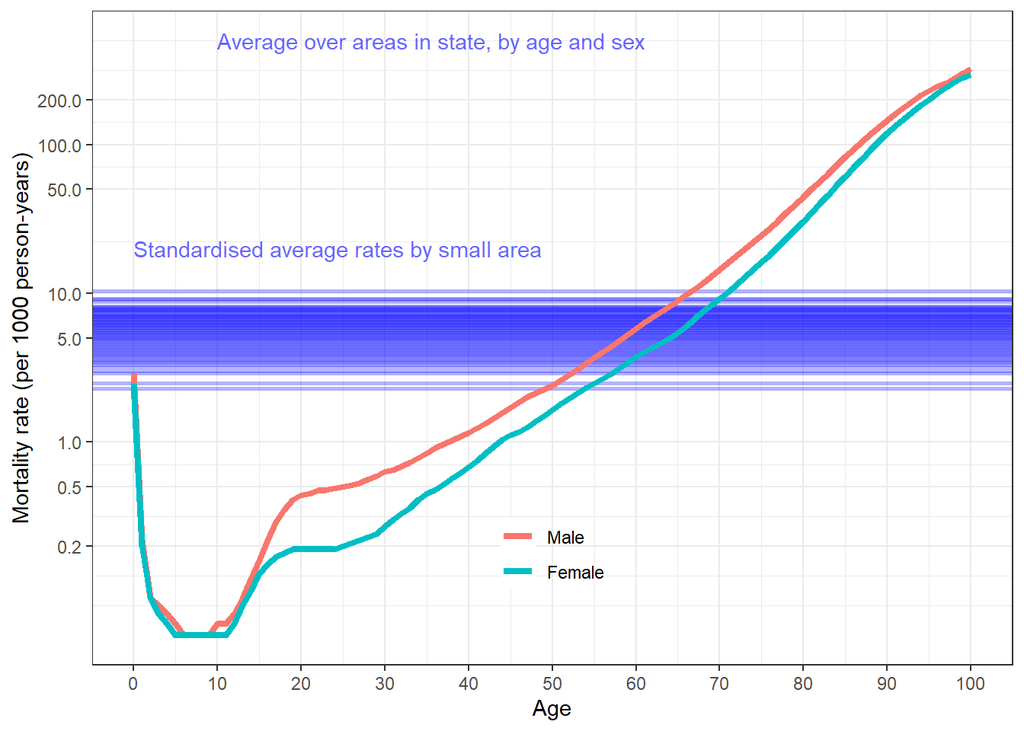

```r
ggplot(victoria_lifetable, aes(x=age, y=rate1000, col=sex)) +
  geom_hline(data=victoria_sa2_deaths, aes(yintercept = stdrate),
             col="blue", alpha=0.3, lwd=1.05) +
  geom_line(lwd=1.5) +
  labs(col="") +
  scale_y_continuous(trans="log",
                     breaks=c(0.0002, 0.0005, 0.001, 0.005,
                              0.01, 0.05, 0.1, 0.2)*1000) +
  scale_x_continuous(breaks=seq(0,100,10)) +
  theme_bw() +
  theme(legend.position = c(0.5, 0.1),
        legend.justification = "bottom",
        legend.background = element_blank()) +
  annotate(geom="text", x=0, y=20,
           label="Standardised average rates by small area",
           col="blue", alpha=0.6, hjust=0) +
  xlab("Age") + ylab("Mortality rate (per 1000 person-years)") +
  annotate(geom="text", x=10, y=500,
           label="Average over areas in state, by age and sex",
           col="blue", alpha=0.6, hjust=0)
```

```r
#saveRDS(victoria_lifetable, "data-r/victoria_lifetable.rds")
```

These are combined as follows to estimate mortality rates by both area and age/sex.

### 3.2.1 Independence model for variations between areas and between age/sex

We assume that the excess mortality risk associated with living in a particular area does not depend on age and sex. We then estimate the area-specific mortality rate for people of a particular age/sex by multiplying the state-wide rate by the area-specific, relative standardised rate.

```r
deaths_age_sa2 <- victoria_lifetable |>
  select(age, sex, rate1000) |>
  cross_join(melbourne_sa2_deaths |>
               select(sa2_code, sa2_name, RR)) |>
  mutate(rate1000 = rate1000*RR,
         area_sex = paste(sa2_code,sex))
```

These are illustrated:

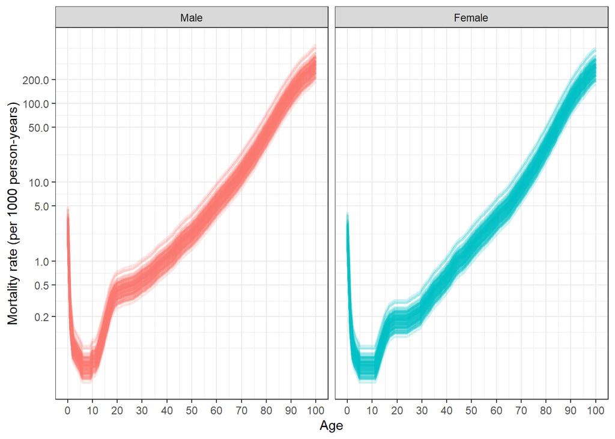

```r
deaths_age_sa2 |>
  filter(sa2_code %in% sample(unique(.data$sa2_code), 100)) |>
  droplevels() |>
ggplot(aes(x=age, y=rate1000, col=sex, group=sa2_code)) +
  geom_line(lwd=1, alpha=0.2) +
  labs(col="") +
  facet_grid(cols=vars(sex)) +
  scale_y_continuous(trans="log",
                     breaks=c(0.0002, 0.0005, 0.001, 0.005, 0.01, 0.05, 0.1, 0.2)*1000) +
  scale_x_continuous(breaks=seq(0,100,10)) +
  theme_bw() +
  theme(legend.position = "none") +
  xlab("Age") + ylab("Mortality rate (per 1000 person-years)")
```

Note that knowing the age balance of each area would not help further to explain these between-area variations, since the age balance is already accounted for in the standardised rates.

### 3.2.2 Including other predictors of mortality

We have previously estimated mortality by age, sex and area. We use this method to further disaggregate mortality rates by level of education, given data on agegroup-specific education effects on mortality and rates of education by area. This assumes that the education effects are independent of year of age (within broad age groups), sex and area.

### 3.2.3 Disaggregating age/sex/area mortality by education

The effects of education on mortality are published for three age groups (25-44, 45-64 and 65-84). Outside these age groups, mortality effects are assumed to be independent of education level.

```r
mort_disagg <- deaths_age_sa2 |>
  left_join(educarea, by="sa2_code") |>
  pivot_longer(cols = c("high","medium","low"),
               names_to = "educ", values_to = "p_educ") |>
  mutate(agegroup = cut(age, c(0, 25, 45, 65, 85, Inf),
                        right=FALSE, include.lowest = TRUE)) |>
  left_join(educ_mort, by=c("agegroup","educ")) |>
  mutate(pRR = rr_educ * p_educ)

sum_p <- mort_disagg |> group_by(age, sa2_code) |>
  summarise(sum_pRR = sum(pRR), .groups="drop")

mort_disagg <- mort_disagg |>
  left_join(sum_p, by=c("age","sa2_code")) |>
  rename(rate_ave_educ = rate1000) |>
  mutate(rate = ifelse(
    between(age, 25, 84) & (!(sa2_code %in% missing_areas)),
    rate_ave_educ * rr_educ / sum_pRR,
    rate_ave_educ),
    prob = 1 - exp(-rate/1000)
  ) |>  select(age, sex, sa2_code, sa2_name, educ, rate, prob) |>
  filter(sa2_code %in% sa2$SA2_MAINCODE_2016[sa2$GCCSA_NAME_2016=="Greater Melbourne"])
saveRDS(mort_disagg, file="health/processed/mort_disagg.rds")
```

The final dataset produced contains the following columns

`age` Year of age

`sex` Sex

`sa2_code` SA2 area code (2016 definitions)

`sa2_name` SA2 area name

`educ` Level of education (low: no secondary school qualification, medium: secondary school but no bachelor’s degree, high: bachelor’s degree)

`rate` Mortality rate per 1000 person-years

`prob` Annual mortality risk

and 187254 rows, one for each of 2 sexes $\times$ 101 years of age $\times$ 3 levels of education $\times$ 309 SA2 areas in Melbourne.

First five rows:

```r
head(mort_disagg, 5)
```

| age | sex | sa2_code | sa2_name | educ | rate | prob |
| --- | --- | --- | --- | --- | --- | --- |
| 0 | Male | 210011227 | Essendon Airport | high | 2.417 | 0.002414 |
| 0 | Male | 210011227 | Essendon Airport | medium | 2.417 | 0.002414 |
| 0 | Male | 210011227 | Essendon Airport | low | 2.417 | 0.002414 |
| 0 | Male | 206041127 | West Melbourne | high | 2.529 | 0.002526 |
| 0 | Male | 206041127 | West Melbourne | medium | 2.529 | 0.002526 |

## 3.3 Summaries of annual mortality probabilities

For each age group, sex and education level, this table shows the median (min-max) annual mortality risk over areas and single years of age.

```r
library(gt)
agecut <- c(0, 18, 45, 65, 80, Inf)
mort_disagg |>
  mutate(agegroup = cut(age, agecut, right=FALSE, include.lowest = TRUE)) |>
  group_by("Age group"=agegroup, "Sex"=sex, "Education"=educ) |>
  summarise(Median = median(prob), Min = min(prob), Max = max(prob), .groups="drop") |>
  gt() |>
  fmt_number(n_sigfig=2) |>
  cols_align_decimal() |>
  cols_merge_range(Min, Max) |>
  cols_label(Min = "Range")
```

| Age group | Sex | Education | Median | Range |
| --- | --- | --- | --- | --- |
| [0,18) | Male | high | 0.000076 | 0.000022–0.0052 |
| [0,18) | Male | low | 0.000076 | 0.000022–0.0052 |
| [0,18) | Male | medium | 0.000076 | 0.000022–0.0052 |
| [0,18) | Female | high | 0.000068 | 0.000022–0.0044 |
| [0,18) | Female | low | 0.000068 | 0.000022–0.0044 |
| [0,18) | Female | medium | 0.000068 | 0.000022–0.0044 |
| [18,45) | Male | high | 0.00013 | 0.000038–0.0015 |
| [18,45) | Male | low | 0.00055 | 0.00016–0.0024 |
| [18,45) | Male | medium | 0.00033 | 0.00010–0.0015 |
| [18,45) | Female | high | 0.000075 | 0.000015–0.00099 |
| [18,45) | Female | low | 0.00025 | 0.000081–0.0016 |
| [18,45) | Female | medium | 0.00017 | 0.000041–0.00099 |
| [45,65) | Male | high | 0.00076 | 0.00020–0.0078 |
| [45,65) | Male | low | 0.0025 | 0.00066–0.011 |
| [45,65) | Male | medium | 0.0014 | 0.00036–0.0078 |
| [45,65) | Female | high | 0.00051 | 0.00013–0.0047 |
| [45,65) | Female | low | 0.0017 | 0.00043–0.0067 |
| [45,65) | Female | medium | 0.00093 | 0.00024–0.0047 |
| [65,80) | Male | high | 0.0054 | 0.0014–0.037 |
| [65,80) | Male | low | 0.011 | 0.0029–0.044 |
| [65,80) | Male | medium | 0.0076 | 0.0020–0.037 |
| [65,80) | Female | high | 0.0035 | 0.00084–0.025 |
| [65,80) | Female | low | 0.0071 | 0.0017–0.030 |
| [65,80) | Female | medium | 0.0049 | 0.0012–0.025 |
| [80,Inf] | Male | high | 0.13 | 0.0069–0.44 |
| [80,Inf] | Male | low | 0.13 | 0.014–0.44 |
| [80,Inf] | Male | medium | 0.13 | 0.0097–0.44 |
| [80,Inf] | Female | high | 0.11 | 0.0047–0.41 |
| [80,Inf] | Female | low | 0.11 | 0.0097–0.41 |
| [80,Inf] | Female | medium | 0.11 | 0.0067–0.41 |